# Part II - (Prosper loans dataset presentation)

## by Saud Almutairi

## Investigation Overview

We have two main questions that we need to answer

> What is the features that has effect on BorrowerAPR?  
> What is the features that has effect on loanstatus?

> **Rubric Tip**: The key insights in the slideshow must match those documented in the README.md summary.

## Dataset Overview

> This data set contains 113,937 loans with 81 variables on each loan, including loan amount, borrower rate (or interest rate), current loan status, borrower income, and many others.

## (Visualization 1)

> Distribution of borrowers Listing categories : The top 5 reasons borrowers request a loan and a listed for are:  
> Debt consolidation ( 1 )  
> Other ( 7 )  
> Not Available ( 0 )  
> Home improvement ( 2 )  
> Business ( 3 )

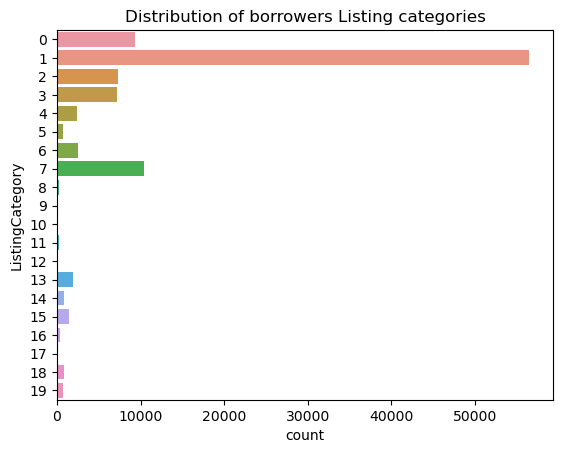

## (Visualization 2)

> What is the Status of a majority of Loans given?  
> The top 4 Status of Loans are:
> 1. **Current**
> 2. **Completed**
> 3. **Chargedoff**
> 4. **Defaulted**

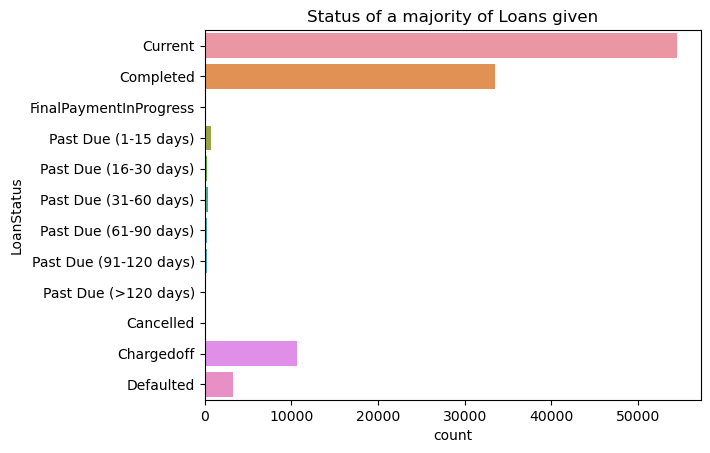

## (Visualization 3)

> Heat map for Bivariate Exploration:
> - We find that about BorrowerAPR There is correlation with Investors and LoanOriginalAmount we can see that. But we can analyze more features in future to check if there is more columns have more correlation than them. and when we see Multivariate Exploration we found the lower BorrowerAPR with teacher Occupation. and Top defaulted happened that has ListingCategory = 0 or 1
> - There is high correlation between MonthlyLoanPayment and LoanOriginalAmount

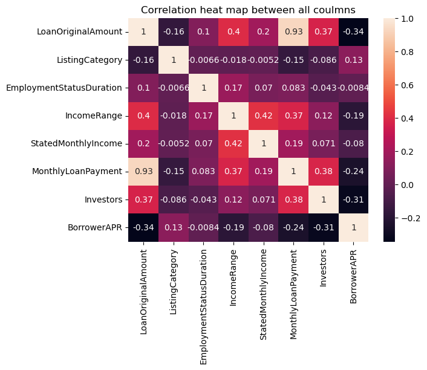

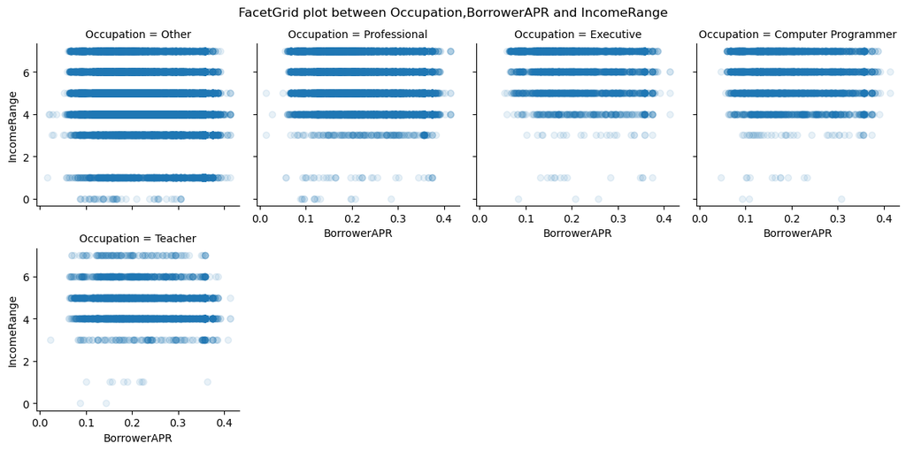

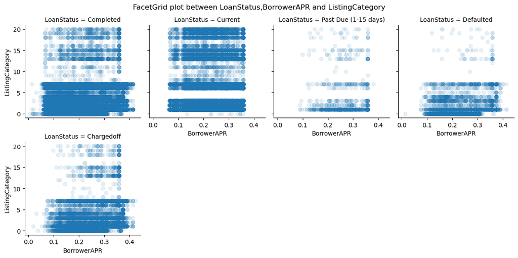

## (Visualization 5)

> Summary table for stats model From P values using multinomial logit we can say that all above feature affect on LoanStatus except StatedMonthlyIncome affect only i can loanStatus ( Completed )

```
                          MNLogit Regression Results
==============================================================================
Dep. Variable:             LoanStatus   No. Observations:               101927
Model:                        MNLogit   Df Residuals:                   101903
Method:                           MLE   Df Model:                           21
Date:                Wed, 08 Feb 2023   Pseudo R-squ.:                  0.1956
Time:                        01:05:34   Log-Likelihood:                -85858.
converged:                       True   LL-Null:                   -1.0674e+05
Covariance Type:            nonrobust   LLR p-value:                     0.000
============================================================================================
            LoanStatus=1       coef    std err          z      P>|z|      [0.025      0.975]
--------------------------------------------------------------------------------------------
LoanOriginalAmount          -0.0005   6.09e-06    -86.344      0.000      -0.001      -0.001
ListingCategory             -0.0392      0.002    -19.633      0.000      -0.043      -0.035
EmploymentStatusDuration    -0.0020   9.31e-05    -21.585      0.000      -0.002      -0.002
IncomeRange                  0.1146      0.007     16.761      0.000       0.101       0.128
StatedMonthlyIncome      -1.324e-05   2.75e-06     -4.815      0.000   -1.86e-05   -7.85e-06
MonthlyLoanPayment           0.0078      0.000     45.341      0.000       0.007       0.008
Investors                    0.0149      0.000    113.647      0.000       0.015       0.015
BorrowerAPR                  0.2357      0.091      2.592      0.010       0.057       0.414
--------------------------------------------------------------------------------------------
            LoanStatus=2       coef    std err          z      P>|z|      [0.025      0.975]
--------------------------------------------------------------------------------------------
LoanOriginalAmount          -0.0005   7.76e-06    -61.430      0.000      -0.000      -0.000
ListingCategory             -0.0714      0.003    -22.443      0.000      -0.078      -0.065
EmploymentStatusDuration    -0.0022      0.000    -15.829      0.000      -0.002      -0.002
IncomeRange                 -0.3546      0.008    -45.692      0.000      -0.370      -0.339
StatedMonthlyIncome       1.659e-06   1.16e-06      1.435      0.151   -6.06e-07    3.92e-06
MonthlyLoanPayment           0.0084      0.000     40.325      0.000       0.008       0.009
Investors                    0.0132      0.000     76.617      0.000       0.013       0.014
BorrowerAPR                  3.8983      0.114     34.124      0.000       3.674       4.122
--------------------------------------------------------------------------------------------
            LoanStatus=3       coef    std err          z      P>|z|      [0.025      0.975]
--------------------------------------------------------------------------------------------
LoanOriginalAmount          -0.0005   1.17e-05    -42.019      0.000      -0.001      -0.000
ListingCategory             -0.1651      0.008    -21.977      0.000      -0.180      -0.150
EmploymentStatusDuration    -0.0023      0.000    -10.024      0.000      -0.003      -0.002
IncomeRange                 -0.3971      0.012    -33.940      0.000      -0.420      -0.374
StatedMonthlyIncome       2.092e-06   1.48e-06      1.410      0.159   -8.16e-07       5e-06
MonthlyLoanPayment           0.0081      0.000     26.335      0.000       0.008       0.009
Investors                    0.0145      0.000     56.921      0.000       0.014       0.015
BorrowerAPR                  0.8466      0.181      4.686      0.000       0.492       1.201
============================================================================================
```